# Data preparation:

This notebook makes plots/analysis of some initial data preparation.

This first section (below) covers the filtering and foldseek outputs. I filtered out amino acids with over 300 AA and also removed ligands, HIS-tags, and water molecules.

Next, I include the initial analysis of the RMSD distributions of a generated synthetic dataset of backbone variations (created with rosetta backrub). This notebook jsut covers the output of a subset of 30 proteins that were used to created 150 conformations. I have a larger compute job to generate 5 conformations per protein in a datset of 300k protein.

Finally, I include some reprsentations from existing "expert" models, protpardelle, which will be used to assess representation alignment. The idea here is to compare how the embeddings will look across different models (recent papers showcase that reprsentations for similar models (eg all the LLMs) are similar, which could be contributed by the fact that these models do have the same baseline transformer architecture and are trained on the same datasets for the most part...In my case, I want to see if protein-related models will also have similar embeddings, and particualrly, how these embeddings will look for "edge" cases such as switch proteins.)

# CATH20 Dataset - Foldseek Structural Analysis

```python
%matplotlib inline

from pathlib import Path

import matplotlib.pyplot as plt
import numpy as np
import pandas as pd
import seaborn as sns
from sklearn.manifold import MDS
from umap import UMAP
```

```python
FOLDSEEK_COLUMNS = [
    "query", "target", "fident", "alnlen", "mismatch", "gapopen",
    "qstart", "qend", "tstart", "tend", "evalue", "bits",
    "alntmscore", "rmsd", "qaln", "taln", "qlen", "tlen",
]


def load_foldseek_results(results_tsv):
    """Load foldseek results TSV into a DataFrame."""
    df = pd.read_csv(results_tsv, sep="\t", header=None, names=FOLDSEEK_COLUMNS)
    df["query"] = df["query"].astype(str).str.replace(r"\.pdb$", "", regex=True)
    df["target"] = df["target"].astype(str).str.replace(r"\.pdb$", "", regex=True)
    return df


def build_pairwise_matrix(df, metric, proteins):
    """Build a symmetric pairwise matrix from alignment results."""
    n = len(proteins)
    prot_idx = {p: i for i, p in enumerate(proteins)}

    if metric == "rmsd":
        mat = np.full((n, n), np.nan)
        np.fill_diagonal(mat, 0.0)
        best = df.groupby(["query", "target"])[metric].min()
    else:
        mat = np.zeros((n, n))
        np.fill_diagonal(mat, 1.0)
        best = df.groupby(["query", "target"])[metric].max()

    for (q, t), val in best.items():
        if q in prot_idx and t in prot_idx:
            i, j = prot_idx[q], prot_idx[t]
            mat[i, j] = val
            mat[j, i] = val

    return mat


def plot_metric_distribution(df, metric, label, units, color="#2a9d8f"):
    """Plot histogram of a structural metric (excluding self-hits)."""
    non_self = df[df["query"] != df["target"]].dropna(subset=[metric])
    vals = non_self[metric]

    fig, ax = plt.subplots(figsize=(9, 4))
    sns.histplot(vals, bins=80, color=color, edgecolor="white", linewidth=0.3, kde=True, ax=ax)
    ax.set_xlabel(f"{label} ({units})")
    ax.set_ylabel("Count")
    ax.set_title(f"{label} distribution (n={len(vals)} non-self alignments)")
    fig.tight_layout()
    plt.show()


def plot_pairwise_heatmap(matrix, proteins, metric_label, cmap="viridis", vmin=None, vmax=None):
    """Plot a pairwise heatmap from a square matrix."""
    n = len(proteins)
    show_labels = n <= 50

    fig, ax = plt.subplots(figsize=(10, 9))
    im = ax.imshow(matrix, cmap=cmap, aspect="auto", vmin=vmin, vmax=vmax)
    fig.colorbar(im, ax=ax, label=metric_label)

    if show_labels:
        ax.set_xticks(range(n))
        ax.set_yticks(range(n))
        ax.set_xticklabels(proteins, rotation=90, fontsize=6)
        ax.set_yticklabels(proteins, fontsize=6)
    else:
        ax.set_xlabel("Protein index")
        ax.set_ylabel("Protein index")

    ax.set_title(f"Pairwise {metric_label} (n={n})")
    fig.tight_layout()
    plt.show()


def plot_correlation_heatmap(df, title="Structural Metric Correlations"):
    """Compute and plot correlation heatmap of structural metrics."""
    non_self = df[df["query"] != df["target"]]
    metrics = {
        "TM-score": "alntmscore",
        "RMSD": "rmsd",
        "Seq Identity": "fident",
        "Alignment Length": "alnlen",
        "E-value": "evalue",
        "Bit Score": "bits",
    }
    metric_df = non_self[list(metrics.values())].rename(columns={v: k for k, v in metrics.items()})
    corr = metric_df.corr(method="pearson")

    fig, ax = plt.subplots(figsize=(8, 7))
    sns.heatmap(corr, annot=True, fmt=".2f", cmap="RdBu_r",
                vmin=-1, vmax=1, center=0, square=True, ax=ax, linewidths=0.5)
    ax.set_title(title)
    fig.tight_layout()
    plt.show()
    display(corr.round(3))
    return corr


def plot_embedding(dist_matrix, proteins, method="UMAP"):
    """Plot a 2D embedding from a distance matrix."""
    mat = dist_matrix.copy()
    mat[np.isnan(mat)] = np.nanmax(mat)
    n = len(proteins)

    if method == "UMAP":
        n_neighbors = min(15, n - 1)
        reducer = UMAP(n_components=2, metric="precomputed", n_neighbors=n_neighbors, random_state=42)
    else:
        reducer = MDS(n_components=2, dissimilarity="precomputed", random_state=42, normalized_stress="auto")

    coords = reducer.fit_transform(mat)

    fig, ax = plt.subplots(figsize=(10, 8))
    ax.scatter(coords[:, 0], coords[:, 1], s=15, alpha=0.7, c="steelblue")
    ax.set_xlabel(f"{method} 1")
    ax.set_ylabel(f"{method} 2")
    ax.set_title(f"{method} embedding of structural similarity (n={n})")

    if n <= 30:
        for i, prot in enumerate(proteins):
            ax.annotate(prot, (coords[i, 0], coords[i, 1]), fontsize=5, alpha=0.7)

    fig.tight_layout()
    plt.show()
    return coords


def plot_residue_alignment_per_protein(df, max_proteins=50):
    """Plot per-protein residue alignment coverage as a bar chart."""
    non_self = df[df["query"] != df["target"]].copy()
    non_self["aln_frac"] = non_self["alnlen"] / non_self["qlen"]
    mean_cov = non_self.groupby("query")["aln_frac"].mean().sort_values(ascending=False)
    mean_cov = mean_cov.head(max_proteins)

    fig, ax = plt.subplots(figsize=(12, max(5, len(mean_cov) * 0.25)))
    ax.barh(range(len(mean_cov)), mean_cov.values, color="steelblue")
    ax.set_yticks(range(len(mean_cov)))
    ax.set_yticklabels(mean_cov.index, fontsize=7)
    ax.set_xlabel("Mean fraction of residues aligned")
    ax.set_title("Per-Protein Residue Alignment Coverage")
    ax.invert_yaxis()
    fig.tight_layout()
    plt.show()
```

## Load CATH20 foldseek results

```python
PDB_DIR = Path("/Users/joycemo/Documents/PhD/Rotation3/dataset/cath20/cath20-filtered-foldseek")
RESULTS_TSV = PDB_DIR / "foldseek_results.tsv"

df = load_foldseek_results(RESULTS_TSV)
all_proteins = sorted(df["query"].unique())
non_self = df[df["query"] != df["target"]]

print(f"Loaded {len(df)} alignments across {len(all_proteins)} unique proteins")
print(f"Non-self alignments: {len(non_self)}")
print()

for col, label in [("alntmscore", "TM-score"), ("rmsd", "RMSD"), ("fident", "Seq identity")]:
    vals = non_self[col].dropna()
    print(f"{label}: mean={vals.mean():.3f}, median={vals.median():.3f}, "
          f"min={vals.min():.3f}, max={vals.max():.3f}")
```

```
Loaded 597057 alignments across 13518 unique proteins
Non-self alignments: 583539

TM-score: mean=0.591, median=0.566, min=0.500, max=1.112
RMSD: mean=4.642, median=4.437, min=0.063, max=40.950
Seq identity: mean=0.141, median=0.131, min=0.000, max=1.000
```

## Distributions

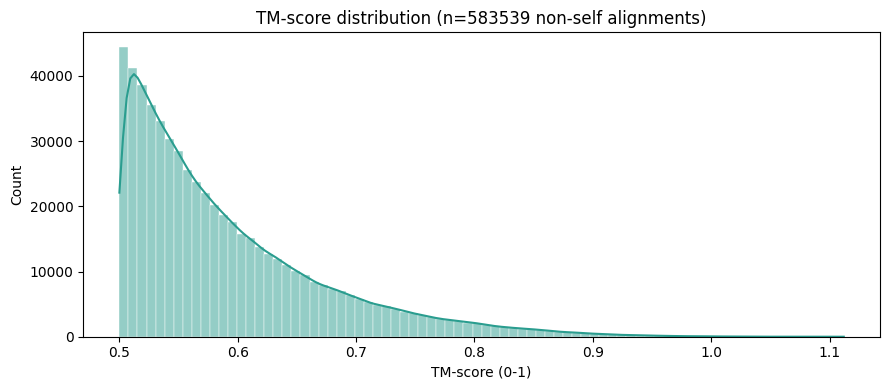

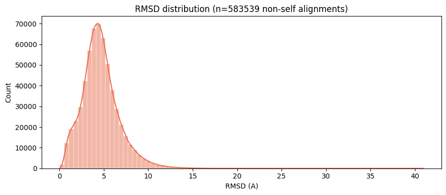

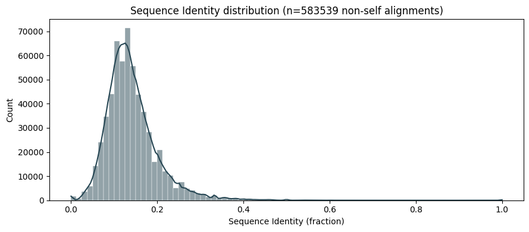

```python
plot_metric_distribution(df, "alntmscore", "TM-score", "0-1", color="#2a9d8f")
plot_metric_distribution(df, "rmsd", "RMSD", "A", color="#e76f51")
plot_metric_distribution(df, "fident", "Sequence Identity", "fraction", color="#264653")
```

## Protein length distribution

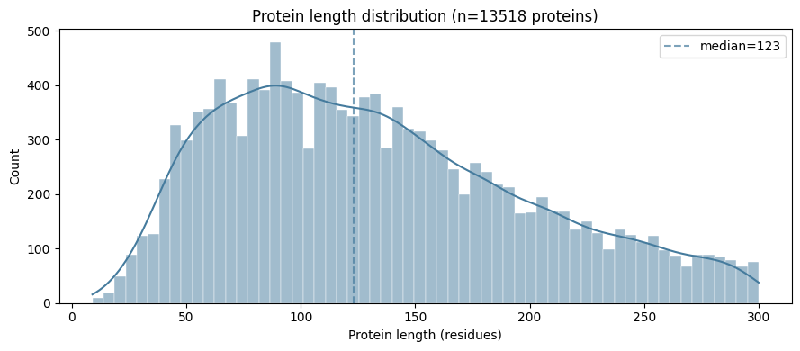

```
Length: mean=133, median=123, min=9, max=300
```

```python
lengths = df.groupby("query")["qlen"].first()

fig, ax = plt.subplots(figsize=(9, 4))
sns.histplot(lengths, bins=60, color="#457b9d", edgecolor="white", linewidth=0.3, kde=True, ax=ax)
ax.set_xlabel("Protein length (residues)")
ax.set_ylabel("Count")
ax.set_title(f"Protein length distribution (n={len(lengths)} proteins)")
ax.axvline(lengths.median(), color="#457b9d", linestyle="--", alpha=0.7, label=f"median={lengths.median():.0f}")
ax.legend()
fig.tight_layout()
plt.show()

print(f"Length: mean={lengths.mean():.0f}, median={lengths.median():.0f}, "
      f"min={lengths.min()}, max={lengths.max()}")
```

## Pairwise heatmaps

Subsampled to 200 proteins for readability.

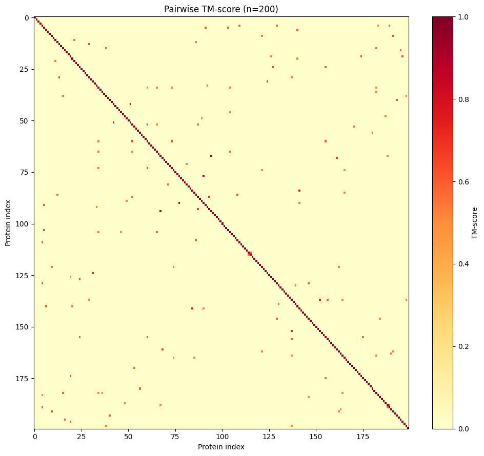

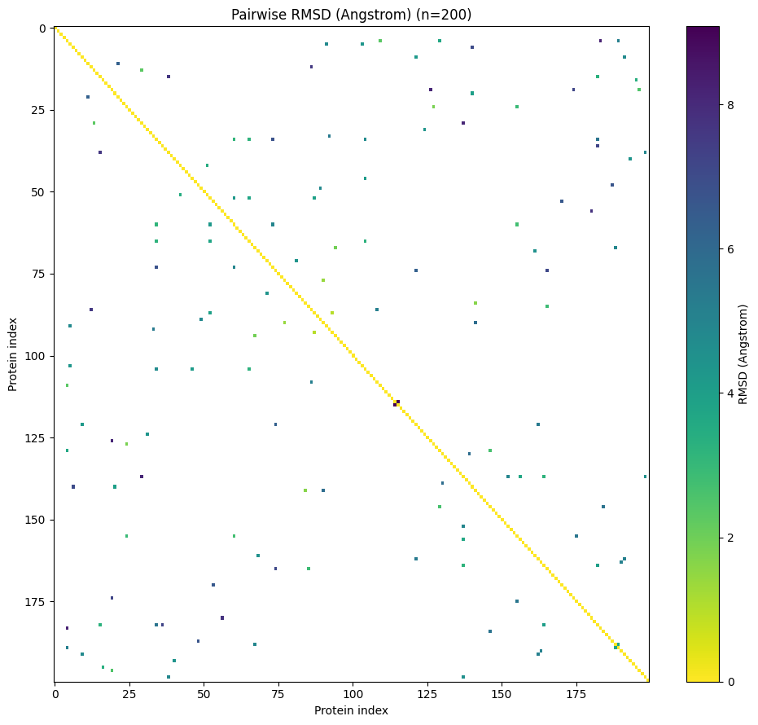

```python
MAX_HEATMAP = 200
heatmap_proteins = all_proteins[:MAX_HEATMAP]

tm_matrix = build_pairwise_matrix(df, "alntmscore", heatmap_proteins)
plot_pairwise_heatmap(tm_matrix, heatmap_proteins, "TM-score", cmap="YlOrRd", vmin=0, vmax=1)

rmsd_matrix = build_pairwise_matrix(df, "rmsd", heatmap_proteins)
plot_pairwise_heatmap(rmsd_matrix, heatmap_proteins, "RMSD (Angstrom)", cmap="viridis_r")
```

## Metric correlations

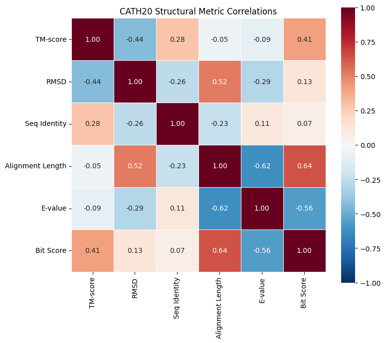

|  | TM-score | RMSD | Seq Identity | Alignment Length | E-value | Bit Score |
| --- | --- | --- | --- | --- | --- | --- |
| TM-score | 1.000 | -0.437 | 0.285 | -0.047 | -0.089 | 0.412 |
| RMSD | -0.437 | 1.000 | -0.263 | 0.516 | -0.291 | 0.130 |
| Seq Identity | 0.285 | -0.263 | 1.000 | -0.234 | 0.113 | 0.067 |
| Alignment Length | -0.047 | 0.516 | -0.234 | 1.000 | -0.623 | 0.637 |
| E-value | -0.089 | -0.291 | 0.113 | -0.623 | 1.000 | -0.558 |
| Bit Score | 0.412 | 0.130 | 0.067 | 0.637 | -0.558 | 1.000 |

```python
_ = plot_correlation_heatmap(df, title="CATH20 Structural Metric Correlations")
```

## Metric scatter plots

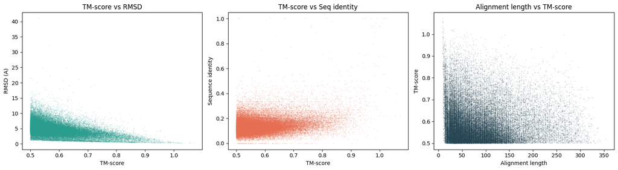

```python
sample = non_self.sample(n=min(50000, len(non_self)), random_state=42)

fig, axes = plt.subplots(1, 3, figsize=(16, 4.5))

axes[0].scatter(sample["alntmscore"], sample["rmsd"], s=1, alpha=0.1, c="#2a9d8f")
axes[0].set_xlabel("TM-score")
axes[0].set_ylabel("RMSD (A)")
axes[0].set_title("TM-score vs RMSD")

axes[1].scatter(sample["alntmscore"], sample["fident"], s=1, alpha=0.1, c="#e76f51")
axes[1].set_xlabel("TM-score")
axes[1].set_ylabel("Sequence identity")
axes[1].set_title("TM-score vs Seq identity")

axes[2].scatter(sample["alnlen"], sample["alntmscore"], s=1, alpha=0.1, c="#264653")
axes[2].set_xlabel("Alignment length")
axes[2].set_ylabel("TM-score")
axes[2].set_title("Alignment length vs TM-score")

fig.tight_layout()
plt.show()
```

## Per-protein alignment connectivity

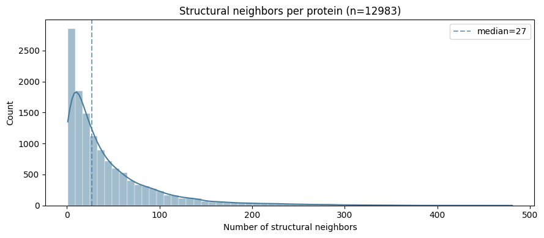

```python
neighbors_per_protein = non_self.groupby("query")["target"].nunique()

fig, ax = plt.subplots(figsize=(9, 4))
sns.histplot(neighbors_per_protein, bins=60, color="#457b9d", edgecolor="white", linewidth=0.3, kde=True, ax=ax)
ax.set_xlabel("Number of structural neighbors")
ax.set_ylabel("Count")
ax.set_title(f"Structural neighbors per protein (n={len(neighbors_per_protein)})")
ax.axvline(neighbors_per_protein.median(), color="#457b9d", linestyle="--", alpha=0.7, label=f"median={neighbors_per_protein.median():.0f}")
ax.legend()
fig.tight_layout()
plt.show()
```

# Backrub Conformer Analysis (ai-cath subset)

Foldseek structural analysis and RMSD quality checks for backrub-generated conformers. Reproduces the analysis from `run_foldseek_backrub.sh`:

1. Foldseek all-vs-all on original structures only
2. Foldseek all-vs-all on originals + backrub conformers combined
3. RMSD analysis (backrub conformers vs their parent originals)

```python
BACKRUB_BASE = Path("/Users/joycemo/Documents/PhD/Rotation3/dataset/ai-cath_subset/analysis")
```

## Foldseek on originals only

All-vs-all structural alignment of the 30 original ai-cath structures.

```python
orig_df = load_foldseek_results(BACKRUB_BASE / "originals" / "foldseek_results.tsv")
orig_proteins = sorted(orig_df["query"].unique())
orig_non_self = orig_df[orig_df["query"] != orig_df["target"]]

print(f"Originals: {len(orig_df)} alignments, {len(orig_proteins)} proteins")
print(f"Non-self: {len(orig_non_self)}")
print()

for col, label in [("alntmscore", "TM-score"), ("rmsd", "RMSD"), ("fident", "Seq identity")]:
    vals = orig_non_self[col].dropna()
    print(f"{label}: mean={vals.mean():.3f}, median={vals.median():.3f}, "
          f"min={vals.min():.3f}, max={vals.max():.3f}")
```

```
Originals: 186 alignments, 30 proteins
Non-self: 156

TM-score: mean=0.782, median=0.760, min=0.503, max=1.485
RMSD: mean=2.229, median=1.561, min=0.098, max=13.300
Seq identity: mean=0.297, median=0.285, min=0.000, max=0.666
```

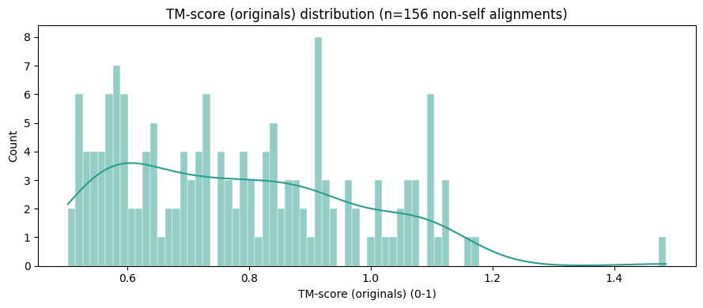

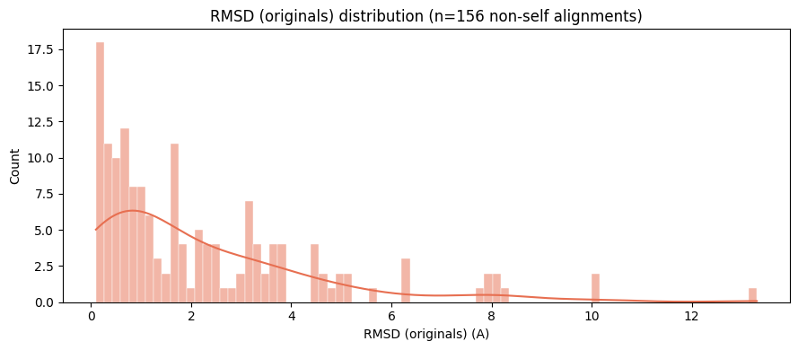

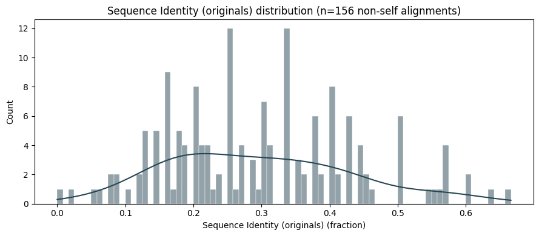

```python
plot_metric_distribution(orig_df, "alntmscore", "TM-score (originals)", "0-1", color="#2a9d8f")
plot_metric_distribution(orig_df, "rmsd", "RMSD (originals)", "A", color="#e76f51")
plot_metric_distribution(orig_df, "fident", "Sequence Identity (originals)", "fraction", color="#264653")
```

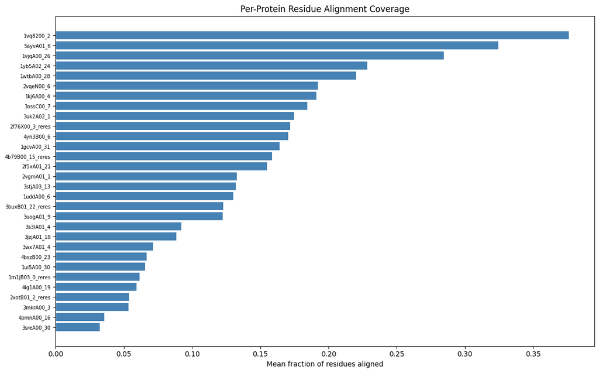

```python
plot_residue_alignment_per_protein(orig_df, max_proteins=30)
```

```python
comb_df = load_foldseek_results(BACKRUB_BASE / "combined" / "foldseek_results.tsv")
comb_proteins = sorted(comb_df["query"].unique())
comb_non_self = comb_df[comb_df["query"] != comb_df["target"]]

print(f"Combined: {len(comb_df)} alignments, {len(comb_proteins)} proteins/conformers")
print(f"Non-self: {len(comb_non_self)}")
print()

for col, label in [("alntmscore", "TM-score"), ("rmsd", "RMSD"), ("fident", "Seq identity")]:
    vals = comb_non_self[col].dropna()
    print(f"{label}: mean={vals.mean():.3f}, median={vals.median():.3f}, "
          f"min={vals.min():.3f}, max={vals.max():.3f}")
```

```
Combined: 186 alignments, 30 proteins/conformers
Non-self: 156

TM-score: mean=0.782, median=0.760, min=0.503, max=1.485
RMSD: mean=2.229, median=1.561, min=0.098, max=13.300
Seq identity: mean=0.297, median=0.285, min=0.000, max=0.666
```

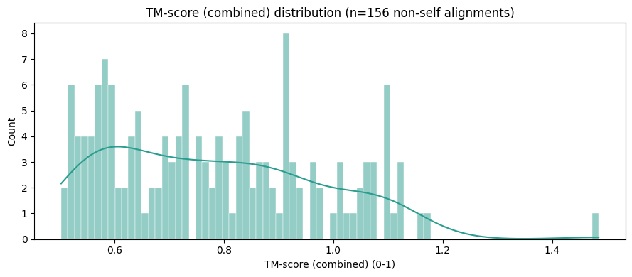

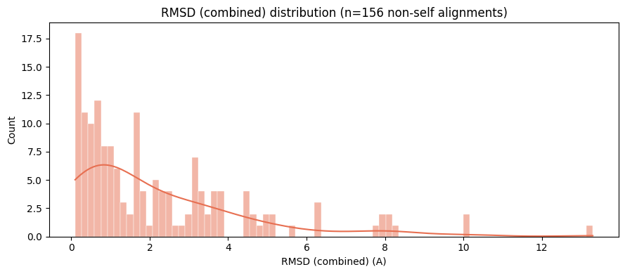

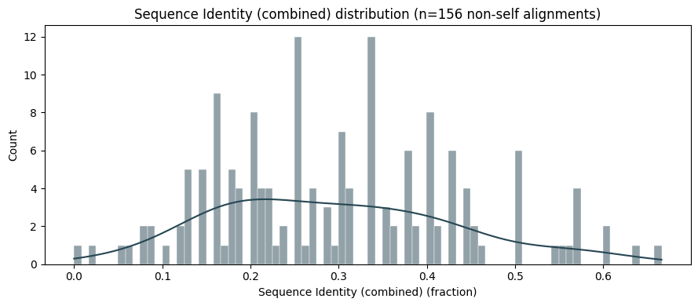

```python
plot_metric_distribution(comb_df, "alntmscore", "TM-score (combined)", "0-1", color="#2a9d8f")
plot_metric_distribution(comb_df, "rmsd", "RMSD (combined)", "A", color="#e76f51")
plot_metric_distribution(comb_df, "fident", "Sequence Identity (combined)", "fraction", color="#264653")
```

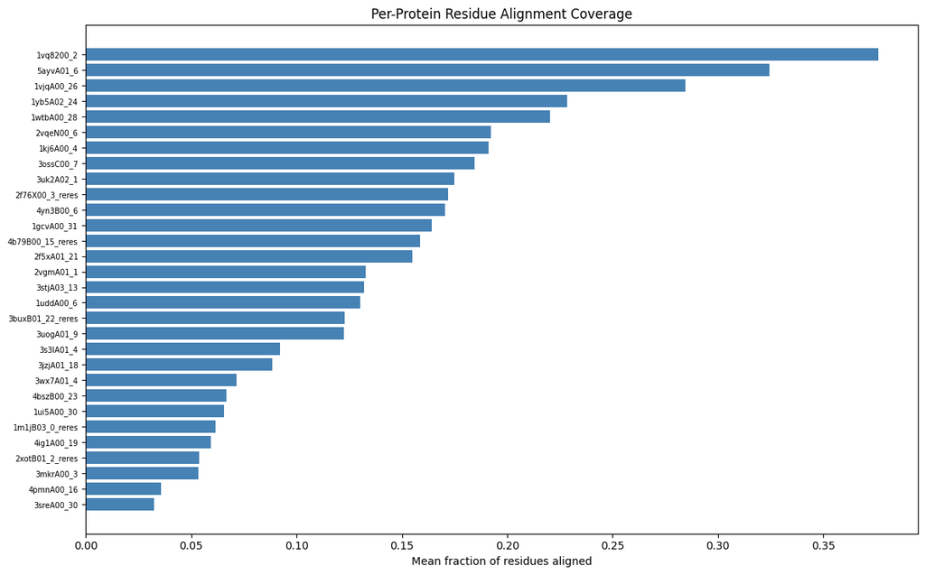

```python
plot_residue_alignment_per_protein(comb_df, max_proteins=50)
```

## Backrub RMSD quality check

Kabsch RMSD and DRMSD between each backrub conformer and its parent original.

```python
rmsd_df = pd.read_csv(BACKRUB_BASE / "rmsd" / "backrub_rmsd.csv")

print(f"Total conformer comparisons: {len(rmsd_df)}")
print(f"Unique proteins: {rmsd_df['protein'].nunique()}")
print()
print(f"RMSD:  mean={rmsd_df['rmsd'].mean():.3f} A, std={rmsd_df['rmsd'].std():.3f}, "
      f"min={rmsd_df['rmsd'].min():.3f}, max={rmsd_df['rmsd'].max():.3f}")
print(f"DRMSD: mean={rmsd_df['drmsd'].mean():.3f} A, std={rmsd_df['drmsd'].std():.3f}, "
      f"min={rmsd_df['drmsd'].min():.3f}, max={rmsd_df['drmsd'].max():.3f}")
```

```
Total conformer comparisons: 150
Unique proteins: 30

RMSD:  mean=2.350 A, std=4.259, min=0.436, max=24.260
DRMSD: mean=1.921 A, std=3.663, min=0.309, max=21.022
```

```python
# Per-protein RMSD summary table
rmsd_summary = rmsd_df.groupby("protein")["rmsd"].agg(["mean", "std", "min", "max", "count"])
display(rmsd_summary.round(3))

print()

# Per-protein DRMSD summary table
drmsd_summary = rmsd_df.groupby("protein")["drmsd"].agg(["mean", "std", "min", "max", "count"])
display(drmsd_summary.round(3))
```

| protein | mean | std | min | max | count |
| --- | --- | --- | --- | --- | --- |
| 1gcvA00_31 | 0.578 | 0.000 | 0.578 | 0.578 | 5 |
| 1kj6A00_4 | 1.965 | 0.034 | 1.919 | 1.989 | 5 |
| 1m1jB03_0_reres | 23.004 | 1.264 | 21.613 | 24.260 | 5 |
| 1uddA00_6 | 0.496 | 0.003 | 0.493 | 0.501 | 5 |
| 1ui5A00_30 | 5.215 | 0.003 | 5.214 | 5.221 | 5 |
| 1vjqA00_26 | 0.595 | 0.000 | 0.595 | 0.595 | 5 |
| 1vq8200_2 | 7.501 | 0.001 | 7.500 | 7.502 | 5 |
| 1wtbA00_28 | 0.828 | 0.011 | 0.821 | 0.848 | 5 |
| 1yb5A02_24 | 0.557 | 0.000 | 0.557 | 0.557 | 5 |
| 2f5xA01_21 | 1.114 | 0.004 | 1.107 | 1.116 | 5 |
| 2f76X00_3_reres | 0.937 | 0.007 | 0.928 | 0.942 | 5 |
| 2vgmA01_1 | 6.618 | 0.469 | 5.873 | 7.024 | 5 |
| 2vqeN00_6 | 4.066 | 0.003 | 4.064 | 4.072 | 5 |
| 2xotB01_2_reres | 0.938 | 0.010 | 0.933 | 0.955 | 5 |
| 3buxB01_22_reres | 1.142 | 0.004 | 1.137 | 1.147 | 5 |
| 3jzjA01_18 | 0.663 | 0.000 | 0.663 | 0.663 | 5 |
| 3mkrA00_3 | 1.217 | 0.000 | 1.217 | 1.217 | 5 |
| 3ossC00_7 | 0.523 | 0.003 | 0.518 | 0.525 | 5 |
| 3s3lA01_4 | 1.008 | 0.002 | 1.004 | 1.009 | 5 |
| 3sreA00_30 | 0.933 | 0.002 | 0.931 | 0.936 | 5 |
| 3stjA03_13 | 0.588 | 0.004 | 0.580 | 0.590 | 5 |
| 3uk2A02_1 | 0.518 | 0.000 | 0.518 | 0.518 | 5 |
| 3uogA01_9 | 1.286 | 0.006 | 1.276 | 1.289 | 5 |
| 3wx7A01_4 | 1.560 | 0.021 | 1.536 | 1.576 | 5 |
| 4b79B00_15_reres | 0.914 | 0.000 | 0.914 | 0.914 | 5 |
| 4bszB00_23 | 0.437 | 0.002 | 0.436 | 0.441 | 5 |
| 4ig1A00_19 | 0.758 | 0.005 | 0.755 | 0.767 | 5 |
| 4pmnA00_16 | 0.784 | 0.009 | 0.778 | 0.799 | 5 |
| 4yn3B00_6 | 3.201 | 0.001 | 3.199 | 3.202 | 5 |
| 5ayvA01_6 | 0.542 | 0.001 | 0.541 | 0.544 | 5 |

| protein | mean | std | min | max | count |
| --- | --- | --- | --- | --- | --- |
| 1gcvA00_31 | 0.479 | 0.001 | 0.479 | 0.480 | 5 |
| 1kj6A00_4 | 1.180 | 0.011 | 1.162 | 1.191 | 5 |
| 1m1jB03_0_reres | 19.548 | 1.484 | 17.906 | 21.022 | 5 |
| 1uddA00_6 | 0.357 | 0.001 | 0.356 | 0.358 | 5 |
| 1ui5A00_30 | 4.053 | 0.007 | 4.050 | 4.065 | 5 |
| 1vjqA00_26 | 0.459 | 0.000 | 0.459 | 0.459 | 5 |
| 1vq8200_2 | 6.798 | 0.002 | 6.796 | 6.799 | 5 |
| 1wtbA00_28 | 0.559 | 0.004 | 0.556 | 0.566 | 5 |
| 1yb5A02_24 | 0.368 | 0.000 | 0.368 | 0.368 | 5 |
| 2f5xA01_21 | 0.890 | 0.002 | 0.887 | 0.891 | 5 |
| 2f76X00_3_reres | 0.618 | 0.007 | 0.608 | 0.623 | 5 |
| 2vgmA01_1 | 5.915 | 0.443 | 5.225 | 6.335 | 5 |
| 2vqeN00_6 | 3.269 | 0.001 | 3.268 | 3.271 | 5 |
| 2xotB01_2_reres | 0.784 | 0.010 | 0.780 | 0.802 | 5 |
| 3buxB01_22_reres | 0.778 | 0.002 | 0.776 | 0.780 | 5 |
| 3jzjA01_18 | 0.535 | 0.000 | 0.535 | 0.535 | 5 |
| 3mkrA00_3 | 0.710 | 0.000 | 0.710 | 0.710 | 5 |
| 3ossC00_7 | 0.463 | 0.005 | 0.454 | 0.465 | 5 |
| 3s3lA01_4 | 0.805 | 0.003 | 0.799 | 0.806 | 5 |
| 3sreA00_30 | 0.707 | 0.001 | 0.706 | 0.709 | 5 |
| 3stjA03_13 | 0.396 | 0.001 | 0.395 | 0.398 | 5 |
| 3uk2A02_1 | 0.357 | 0.001 | 0.355 | 0.357 | 5 |
| 3uogA01_9 | 0.940 | 0.003 | 0.935 | 0.944 | 5 |
| 3wx7A01_4 | 1.448 | 0.020 | 1.426 | 1.463 | 5 |
| 4b79B00_15_reres | 0.874 | 0.000 | 0.874 | 0.874 | 5 |
| 4bszB00_23 | 0.309 | 0.001 | 0.309 | 0.312 | 5 |
| 4ig1A00_19 | 0.543 | 0.008 | 0.539 | 0.558 | 5 |
| 4pmnA00_16 | 0.573 | 0.009 | 0.566 | 0.587 | 5 |
| 4yn3B00_6 | 2.522 | 0.001 | 2.520 | 2.523 | 5 |
| 5ayvA01_6 | 0.398 | 0.000 | 0.398 | 0.399 | 5 |

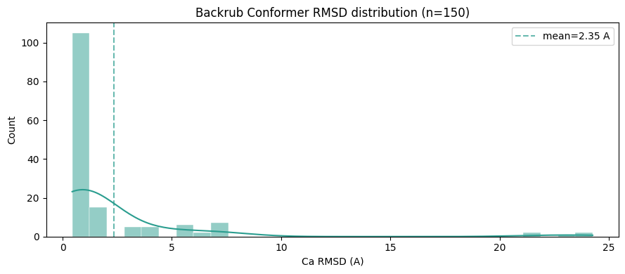

```
RMSD: mean=2.350, median=0.933, min=0.436, max=24.260
```

```python
# RMSD histogram
fig, ax = plt.subplots(figsize=(9, 4))
sns.histplot(rmsd_df["rmsd"].dropna(), bins=30, color="#2a9d8f", edgecolor="white",
             linewidth=0.3, kde=True, ax=ax)
ax.axvline(rmsd_df["rmsd"].mean(), color="#2a9d8f", linestyle="--", alpha=0.7,
           label=f"mean={rmsd_df['rmsd'].mean():.2f} A")
ax.set_xlabel("Ca RMSD (A)")
ax.set_ylabel("Count")
ax.set_title(f"Backrub Conformer RMSD distribution (n={len(rmsd_df)})")
ax.legend()
fig.tight_layout()
plt.show()

print(f"RMSD: mean={rmsd_df['rmsd'].mean():.3f}, median={rmsd_df['rmsd'].median():.3f}, "
      f"min={rmsd_df['rmsd'].min():.3f}, max={rmsd_df['rmsd'].max():.3f}")
```

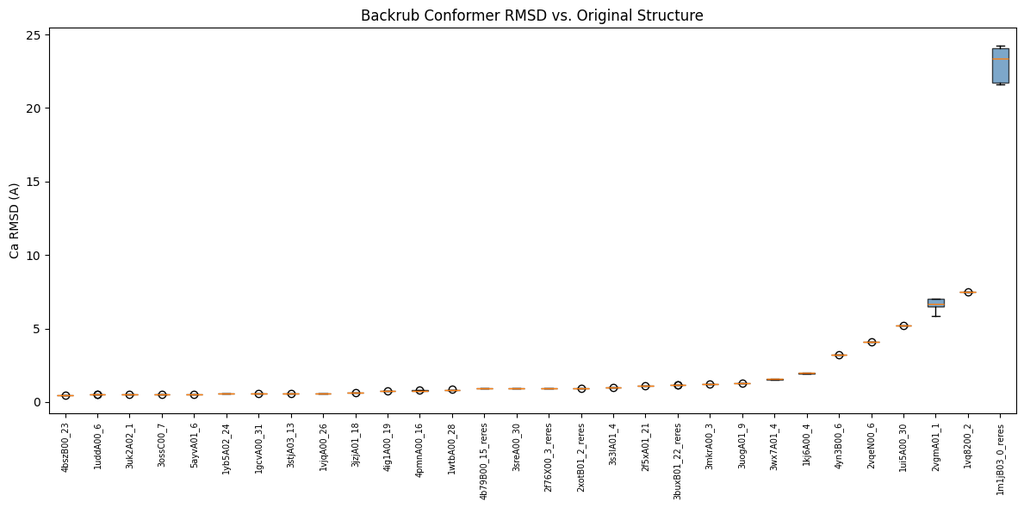

```python
# RMSD box plot per protein
proteins_sorted = rmsd_df.groupby("protein")["rmsd"].mean().sort_values().index.tolist()

fig, ax = plt.subplots(figsize=(max(8, len(proteins_sorted) * 0.4), 6))
df_plot = rmsd_df.set_index("protein").loc[proteins_sorted].reset_index()
bp = ax.boxplot(
    [df_plot[df_plot["protein"] == p]["rmsd"].values for p in proteins_sorted],
    labels=proteins_sorted,
    patch_artist=True,
)
for patch in bp["boxes"]:
    patch.set_facecolor("steelblue")
    patch.set_alpha(0.7)

ax.set_xticklabels(proteins_sorted, rotation=90, fontsize=7)
ax.set_ylabel("Ca RMSD (A)")
ax.set_title("Backrub Conformer RMSD vs. Original Structure")
fig.tight_layout()
plt.show()
```

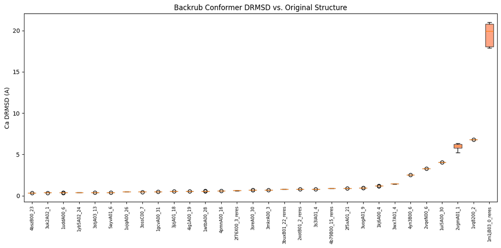

```python
# DRMSD box plot per protein
proteins_sorted_d = rmsd_df.groupby("protein")["drmsd"].mean().sort_values().index.tolist()

fig, ax = plt.subplots(figsize=(max(8, len(proteins_sorted_d) * 0.4), 6))
df_plot_d = rmsd_df.set_index("protein").loc[proteins_sorted_d].reset_index()
bp = ax.boxplot(
    [df_plot_d[df_plot_d["protein"] == p]["drmsd"].values for p in proteins_sorted_d],
    labels=proteins_sorted_d,
    patch_artist=True,
)
for patch in bp["boxes"]:
    patch.set_facecolor("coral")
    patch.set_alpha(0.7)

ax.set_xticklabels(proteins_sorted_d, rotation=90, fontsize=7)
ax.set_ylabel("Ca DRMSD (A)")
ax.set_title("Backrub Conformer DRMSD vs. Original Structure")
fig.tight_layout()
plt.show()
```

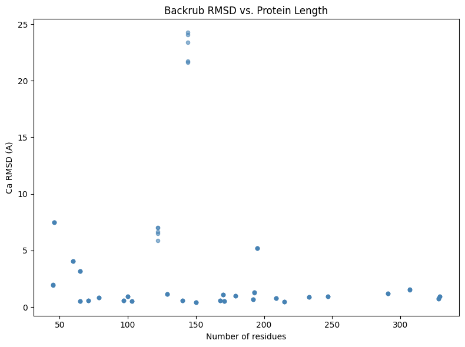

```python
# RMSD vs protein length scatter
fig, ax = plt.subplots(figsize=(8, 6))
ax.scatter(rmsd_df["n_residues"], rmsd_df["rmsd"], s=20, alpha=0.6, c="steelblue")
ax.set_xlabel("Number of residues")
ax.set_ylabel("Ca RMSD (A)")
ax.set_title("Backrub RMSD vs. Protein Length")
fig.tight_layout()
plt.show()
```

# Protpardelle representation UMAPs

use `umap_representations.py` on two sets of extracted embeddings to visualize how the model's internal representations organize residues.

These embeddings/representations will be used for representation alignment. it will alos be used to compare how well a VAE's latent representations will compare to these other embeddings -> questions of what is the best way to represent protein structure data for diffusion models?

## UMAP of march_rep_test embeddings

Representations from: `/Users/joycemo/Documents/GitHub/protpardelle-1c/results/march_rep_test`

```python
import subprocess, sys

UMAP_SCRIPT = "/Users/joycemo/Documents/GitHub/protpardelle-1c/representation_extraction/umap_representations.py"

result = subprocess.run(
    [
        sys.executable, UMAP_SCRIPT,
        "--rep-dir", "/Users/joycemo/Documents/GitHub/protpardelle-1c/results/march_rep_test/per_structure",
        "--output-dir", "output/umap_march_rep_test",
        "--module", "transformer_output",
        "--step", "-1",
        "--max-residues", "200000",
    ],
    capture_output=True, text=True,
)
print(result.stdout)
if result.stderr:
    print(result.stderr)
```

```
Found 5 structures in /Users/joycemo/Documents/GitHub/protpardelle-1c/results/march_rep_test/per_structure
Loaded 470 residue embeddings (256D) from 5 structures
Running UMAP (n_neighbors=100, min_dist=0.3, metric=euclidean, n=470) ...
Saved 7 UMAP plots to output/umap_march_rep_test/
```

```
transformer_output_step-1_by_aa.png
```

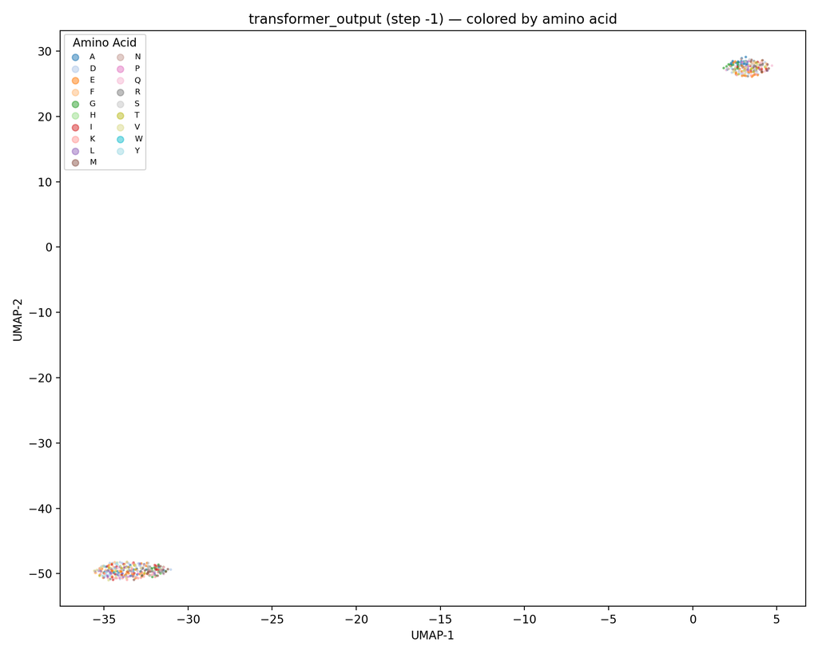

```
transformer_output_step-1_by_aa_group.png
```

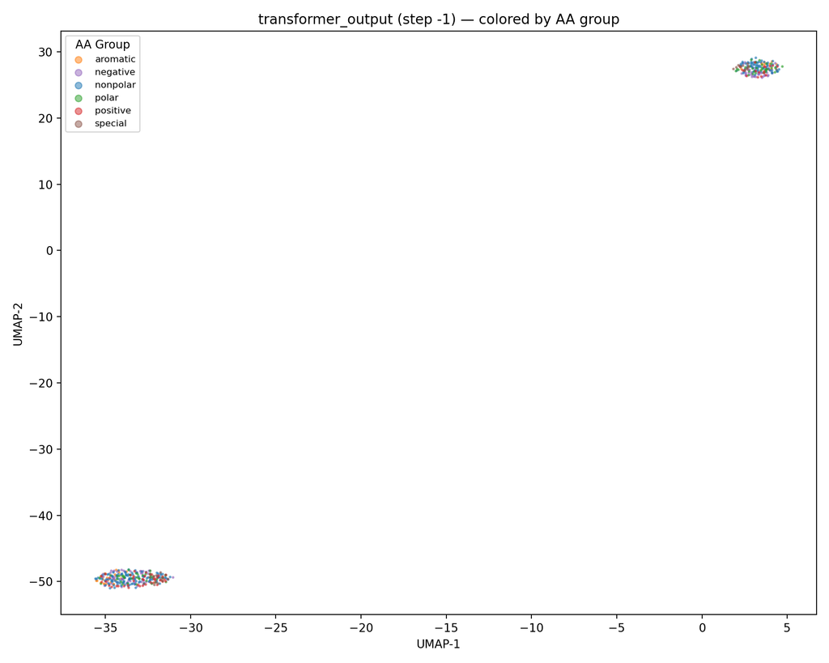

```
transformer_output_step-1_by_charge.png
```

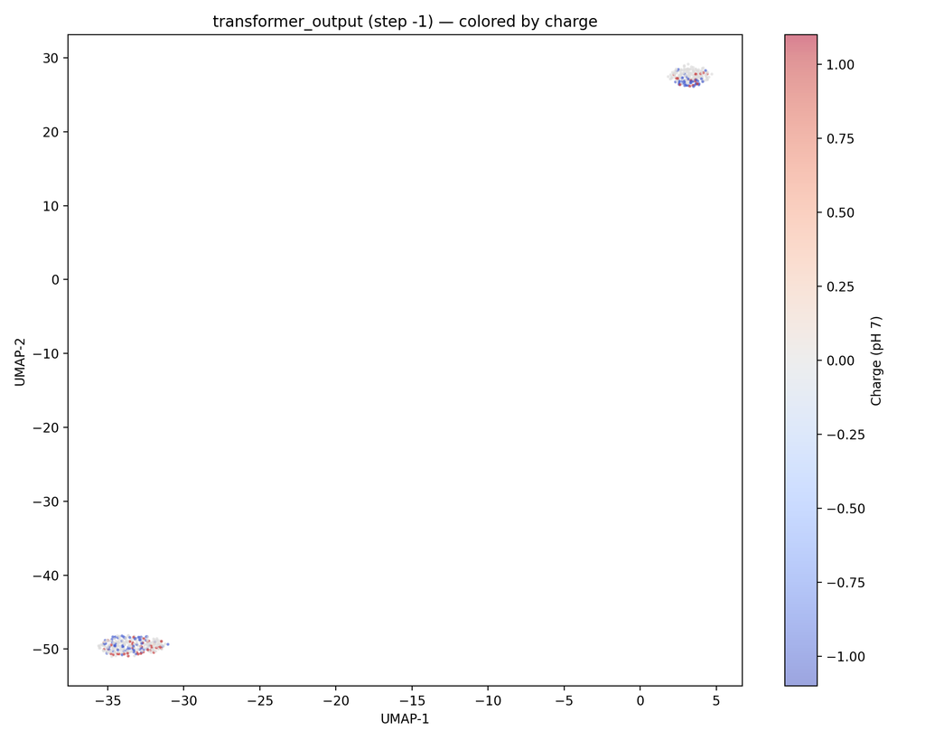

```
transformer_output_step-1_by_dist_to_center.png
```

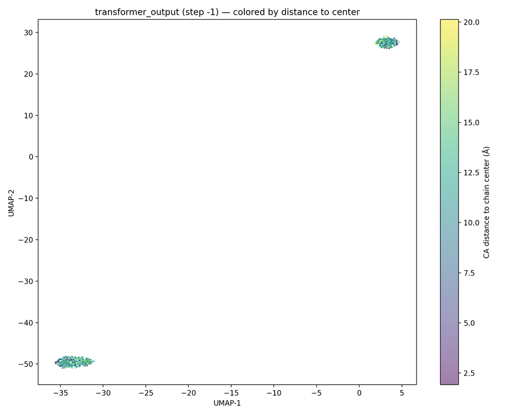

```
transformer_output_step-1_by_hydrophobicity.png
```

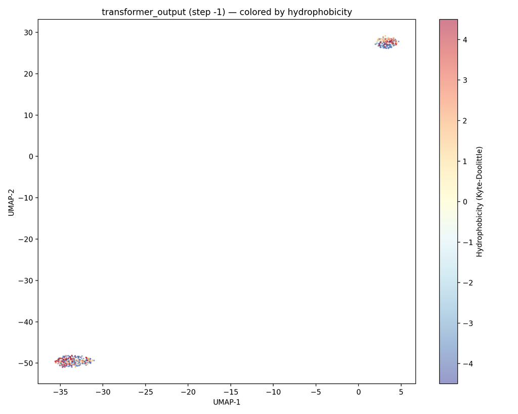

```
transformer_output_step-1_by_mean_pw_dist.png
```

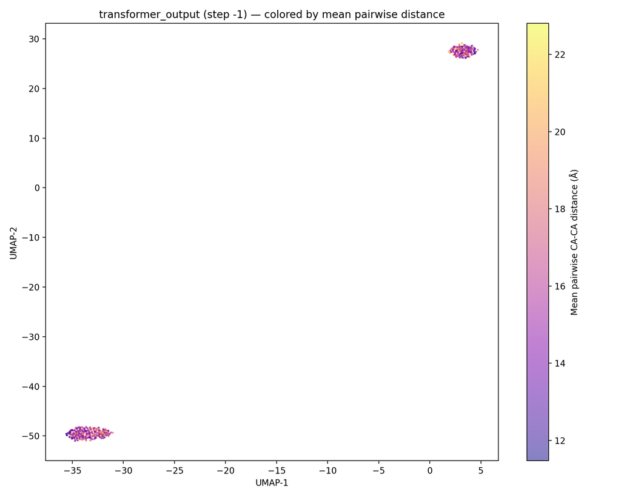

```
transformer_output_step-1_by_sasa.png
```

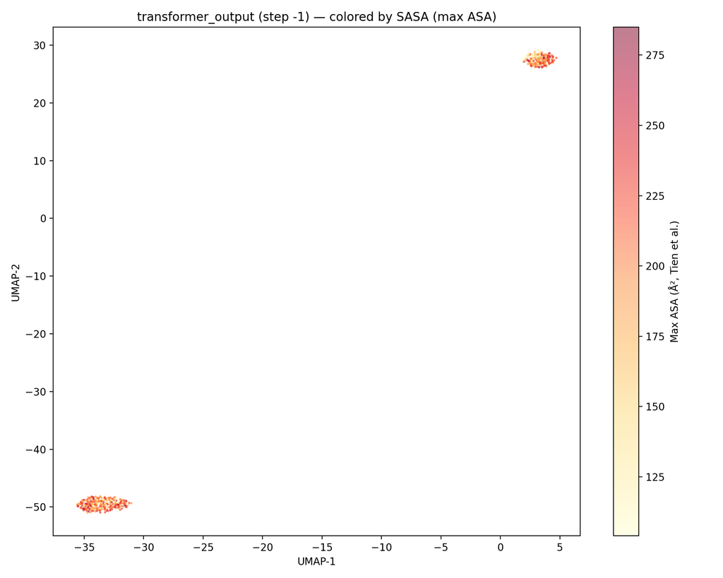

```python
from IPython.display import Image, display

umap_dir = Path("output/umap_march_rep_test")
for fig_path in sorted(umap_dir.glob("*.png")):
    print(fig_path.name)
    display(Image(filename=str(fig_path), width=600))
```

## UMAP of CATH20 Protpardelle representations

Representations from: `/Users/joycemo/Documents/PhD/Rotation3/cath20_representations/protpardelle`

This takes a long time to run and so I will just run this on Wynton.

```python
result = subprocess.run(
    [
        sys.executable, UMAP_SCRIPT,
        "--rep-dir", "/Users/joycemo/Documents/PhD/Rotation3/cath20_representations/protpardelle/per_structure",
        "--output-dir", "output/umap_cath20_protpardelle",
        "--module", "transformer_output",
        "--step", "-1",
        "--max-residues", "200000",
    ],
    capture_output=True, text=True,
)
print(result.stdout)
if result.stderr:
    print(result.stderr)
```

```
Found 566 structures in /Users/joycemo/Documents/PhD/Rotation3/cath20_representations/protpardelle/per_structure
Loaded 78262 residue embeddings (256D) from 565 structures
Running UMAP (n_neighbors=100, min_dist=0.3, metric=euclidean, n=78262) ...
Saved 7 UMAP plots to output/umap_cath20_protpardelle/
```